# Lab 13 - Logistic and Softmax Regression, and more gradient descent

This lab will introduce both logistic and softmax regression in `sklearn`. It will also provide a demonstration and some practice implementing stochastic gradient descent to solve for optimal weights in a logistic regression model.

```python
import pandas as pd
import numpy as np
import matplotlib.pyplot as plt
import sklearn
import math
```

As it turns out, logistic (and softmax) regression can be challenging to work with for a few different reasons. We'll use the MNIST handwritten digits data (introduced in a few earlier labs) to illustrate some of these challenges:

```python
### Read flattened, processed MNIST data
mnist = pd.read_csv("https://remiller1450.github.io/data/mnist_small.csv")

## Train-test split
from sklearn.model_selection import train_test_split
train, test = train_test_split(mnist, test_size=0.2, random_state=5)

### Separate the label column (outcome)
train_y = train['label']
train_X = train.drop(['label'], axis="columns")

### Create a binary label for 8's
train_y_binary = (train_y == 8).astype(int)
```

To demonstrate logistic regression, which involves a binary outcome variable, we've created `train_y_binary` to provide a separate label for digits that are an "8" versus all other digits.

## Part 1 - Logistic Regression in `sklearn`

The `LogisticRegression()` function in `sklearn` is largely similar to `LinearRegression()` with a few key differences:

1. By default the model imposes a penalty on the estimated weights, an concept known as regularization that we'll discuss in our next lecture. We can turn this off using the argument `penalty = None` (or `penalty = 'none'` in older versions of `sklearn`).
2. The estimated weights in logistic regression must be found using an iterative algorithm, and there are several variations of gradient descent that we can choose from.

```python
from sklearn.linear_model import LogisticRegression
from sklearn.pipeline import Pipeline

pipe = Pipeline([
('model', LogisticRegression(penalty=None))
])

log_mod = pipe.fit(train_X, train_y_binary)
```

This happens somewhat frequently with logistic regression, and there are several reasons why, with the major problems being either:

1. Numerical instability
2. Perfect separation

If we suspect numerical instability, we can try re-scaling the data and using an algorithm that is more precise. Without getting too far into the details, we can change our solver to "newton-cg", which calculates the entire [hessian matrix](https://en.wikipedia.org/wiki/Hessian_matrix) of second order partial derivatives rather than trying to approximate (as is done by the default choice of "lbfgs").

```python
## Try a different solver w/ scaling
from sklearn.preprocessing import MinMaxScaler
pipe = Pipeline([
('scaler', MinMaxScaler()),
('model', LogisticRegression(penalty=None, solver='newton-cg'))
])

log_mod = pipe.fit(train_X, train_y_binary)
log_mod.score(train_X, train_y_binary)
```

```
1.0
```

Unfortunately these changes still do not allow us to coverge to a set of optimal weights.

However, by checking the in-sample classification accuracy we can see that the weights in the final iteration were such that perfect classification of the training data was achieved. Thus, "perfect separation" was likely the reason for logistic regression struggling to converge in this application.

**Question 1**: The previous demonstration checked the in-sample classification accuracy of our model (which we know didn't converge). We might wonder how generalizable this model given the uncertainty surrounding the estimated weights.

- **Part A**: Create a confusion matrix of cross-validated predictions for the outcome `train_y_binary` using the model that was trained above. In doing so, consider the outcome being an "8" as the positive class.
- **Part B**: Using your results from Part A, show the calculation of this model's F1 score "by hand".
- **Part C**: Display an ROC curve created using cross-validated prediction scores (probabilities). Briefly comment upon the effectiveness of this logistic regression model given what you see in the ROC curve.

## Part 2 - Softmax Regression

To perform softmax regression, which is used for multi-label classification, we simply use `LogisticRegression()` with the additional argument `multi_class='multinomial'`:

```python
## Modify pipeline to fit softmax regression
pipe = Pipeline([
('scaler', MinMaxScaler()),
('model', LogisticRegression(penalty=None, multi_class='multinomial'))
])

sm_mod = pipe.fit(train_X, train_y)
sm_mod.score(train_X, train_y)
```

```
1.0
```

While the perfect classification accuracy we see in the training data might seem suspicious, cross-validation suggests this is just overfitting:

```python
from sklearn.model_selection import cross_validate
cv_res = cross_validate(sm_mod, train_X, train_y, cv = 5, scoring = 'accuracy')
np.average(cv_res['test_score'])
```

```
0.8652083333333334
```

**Question 2**: Use pipelines and 5-fold cross-validation to compare the performance of softmax regression with $k$-nearest neighbors using `n_neighbors=20`, distance weighting, and euclidean distance calculations on the MNIST data. Use min-max scaling as a preprocessing step in your pipeline to promote numerical stability. Report a cross-validated F1-score calculated using macro-averaging for each model.

### Part 3 - Weights and predictions

In logistic regression, the prediction scores (ie: $\mathbf{x}_i^T\mathbf{w}$ for the $i^{th}$ observation) are linked to probabilities of the positive class via the *sigmoid function*:

$$log\big(\tfrac{\pi_i}{1-\pi_i}\big) = \mathbf{x}_i^T\mathbf{w}$$

In this expression $Pr(Y=1)$ is denoted by $\pi$. For future calculations, we can denote $z_i = \mathbf{x}_i^T\mathbf{w}$ and recognize:

$$\pi_i = g(z_i) = \tfrac{1}{1 + exp(-\mathbf{x}_i^T\mathbf{w})}$$

We can verify this relationship by manually calculating prediction scores/probabilities and comparing them with the output returned by `LogisticRegression`:

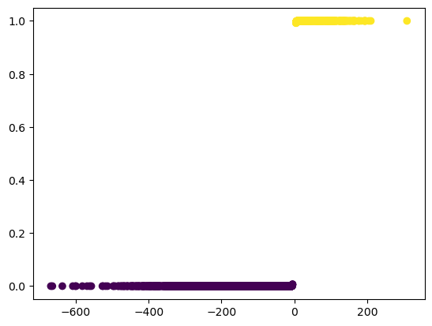

```python
## Refit logistic regression
pipe = Pipeline([
('scaler', MinMaxScaler()),
('model', LogisticRegression(penalty=None, solver='newton-cg'))
])
log_mod = pipe.fit(train_X, train_y_binary)

## Store the weights and bias
w = log_mod.named_steps['model'].coef_
b = log_mod.named_steps['model'].intercept_

## Calculate eta manually using the dot product of X and w + the bias term
train_Xs =  MinMaxScaler().fit_transform(train_X)
z = np.dot(train_Xs, np.transpose(w)) + b

## Use z to calculate probabilities of the positive class
pi = 1/(1 + np.exp(-z))

## Display relationship between z and pi
plt.scatter(z, pi, c=train_y_binary.astype('category'))
plt.show()
```

We can compare this graph to one created using predicted probabilities found using the `predict_proba()` method of our fitted model:

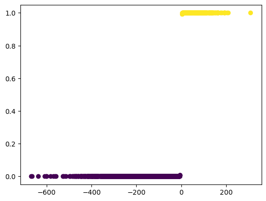

```python
## predicted probabilities using `predict_proba`:
pi_m = log_mod.named_steps['model'].predict_proba(train_Xs)
plt.scatter(z, pi_m[:,1], c=train_y_binary.astype('category'))
plt.show()
```

These graphs should give us confidence that the manner by which we calculated predicted probabilities "by hand" is correct.

However, due to the problems with perfect separation in these data the sigmoid relationship between the linear predictor and predicted probability of the positive class isn't clear. Thus, we'll quickly look at a second example with a more typical relationship between $z$ and $Pr(Y=1)$:

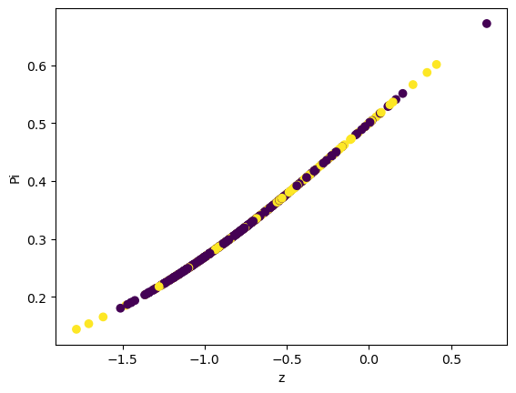

```python
## Load data
ic = pd.read_csv("https://remiller1450.github.io/data/IowaCityHomeSales.csv")
train_ic, test_ic = train_test_split(ic, test_size=0.2, random_state=7)

## Create X and y
train_num = train_ic.select_dtypes("number")
train_ic_y = (train_num['assessed'] > train_num['sale.amount']).astype(int)
train_ic_X = train_num.drop(['assessed','sale.amount'],axis=1)

## Fit logistic regression
pipe = Pipeline([
('scaler', MinMaxScaler()),
('model', LogisticRegression(penalty=None, solver='newton-cg'))
])
ic_log_mod = pipe.fit(train_ic_X, train_ic_y)

## Store the weights and bias
w = ic_log_mod.named_steps['model'].coef_
b = ic_log_mod.named_steps['model'].intercept_

## Calculate eta manually using the dot product of X and w + the bias term
train_Xs =  MinMaxScaler().fit_transform(train_ic_X)
z = np.dot(train_Xs, np.transpose(w)) + b

## Use eta to calculate probabilities of the positive class
pi = 1/(1 + np.exp(-z))

## Display
plt.scatter(z, pi, c=train_ic_y.astype('category'))
plt.xlabel("z")
plt.ylabel("Pi")
plt.show()
```

**Question 3**: In our second application we did not calculate the in-sample classification accuracy of the model, while in our first example we found an in-sample classification accuracy of 100%. Using just the graphs of $z$ vs. $Pr(Y=1)$, briefly explain how you can tell that the classifier in the second application (Iowa City home assessments) will achieve substantially lower in-sample classification accuracy. Do not justify your answer by calculating the classification accuracy, instead your justification should only involve the relationship you see between $z$, $Pr(Y=1)$, and $\mathbf{y}$.

## Part 4 - Interpreting Weights

A strength of logistic regression relative to other binary classifiers is the ability to interpret and understand each of the estimated weights. By virtue of the model's form, we see:

$$log\big(\tfrac{\pi}{1-\pi}\big) = w_0 + w_1X_1 + \ldots + w_pX_p $$$$\implies \tfrac{\pi}{1-\pi} = exp(w_0 + w_1X_1 + \ldots + w_pX_p)$$$$\implies \tfrac{\pi}{1-\pi} = exp(w_0)*exp(w_1X_1)* \ldots *exp(w_pX_p)$$

The left-hand side of this equation, $\tfrac{\pi}{1-\pi}$, is the [odds](https://en.wikipedia.org/wiki/Odds) of an observation belonging to the positive class.

- The exponent of the bias, $exp(w_0)$, reflects the *baseline odds* of the positive class.
- The exponent of $w_p$ reflects the *multiplicative effect* of a 1-unit change in the predictor $X_p$ on the odds of an observation belonging to the positive class.

For example, suppose a predictor's weight is 0.44. We can calculate $e^{0.44} = 1.55$, indicating that a 1-unit change in this predictor corresponds with an estimated 55% increase in the odds of an observation belonging to the positive class.

When interpreting weights, it is important to consider whether you've re-scaled the data during the model building process. If you've applied standardization, 1-unit change is actually a 1-standard deviation change in the predictor in terms of its original units. If you've applied min-max scaling, a 1-unit change reflects going from the minimum observed value to the maximum observed value.

**Question #4**: Using the logistic regression model fit to the Iowa City Home Sales data in example at the end of Part 3, (ie: the model stored in `ic_log_mod`), find the estimated weight for the predictor 'bedrooms' and interpret this weight after exponentiation.

### Part 5 - Optimization and Stochastic Gradient Descent

Unlike linear regression, neither logistic nor softmax regression have a closed form solution, so weights must be estimated using iterative algorithms. As you've already seen in this lab, there are many different algorithms capable of solving for an optimal set of weights. Note that an optimal set does exist so long as there isn't perfect separation in the data, otherwise there might be several different equally effective solutions. Even if there are many solutions, the *cross entropy cost function* itself has a single minimum value, there just might be several ways to achieve that minimum.

In this section of the lab, we'll explore the process of solving for these weights. To begin, we need to define the cost function:

$$Cost = -\tfrac{1}{n}\sum_{i=1}^{n}\big(y_ilog(g(z_i)) + (1-y_i)log(1-g(z_i))\big)$$

$$Gradient = (g(z_i)-y)\mathbf{x}_i$$

Here $\mathbf{x}_i$ is the row vector corresponding to the single observation we're considering in the update step.

The code below demonstrates *stochastic gradient descent* for the Iowa City Home Sales data. You should reference this code during *Question #5* (which appears at the end of this section).

```python
## First, reload IC data
ic = pd.read_csv("https://remiller1450.github.io/data/IowaCityHomeSales.csv")

## Train-test split
train_ic, test_ic = train_test_split(ic, test_size=0.2, random_state=7)

## Recreate X and Y
train_num = train_ic.select_dtypes("number")
train_ic_y = (train_num['assessed'] > train_num['sale.amount']).astype(int)
train_ic_X = train_num.drop(['assessed','sale.amount'],axis=1)
train_Xs =  MinMaxScaler().fit_transform(train_ic_X)
```

```python
## Define Functions to calculate cost and peform grad descent
import random
def cost_function(x, y, w):
    eta = np.dot(x,w)
    pred_y = 1/(1 + np.exp(-eta))
    cost = -y*np.log(pred_y) - (1-y)*np.log(1-pred_y)
    return cost

def grad_descent(X, y, w, alpha, n_iter):
    n = len(y)
    costs = np.zeros(n_iter)

    for i in range(n_iter):
        idx = random.sample(range(n), n)
        temp_cost = 0.0

        for si in range(n):
            random_y = y.iloc[idx[si]]
            random_x = np.append(1,X[idx[si],:])
            eta = np.dot(random_x,w)
            pred_y = 1/(1 + np.exp(-eta))
            err =  (pred_y - random_y).item()
            grad = random_x*err
            w = w - alpha*grad
            temp_cost += cost_function(random_x, random_y, w)

        costs[i] = temp_cost
    return w, costs
```

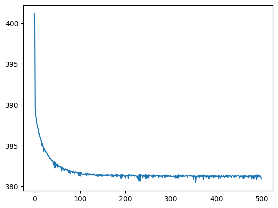

```python
## Run 500 epochs and plot the results
p = np.shape(train_Xs)[1]+1
n = len(train_ic_y)
nit = 500
gdres = grad_descent(X=train_Xs,y=train_ic_y,w=np.zeros(p),alpha=0.005, n_iter = nit)
plt.plot(np.linspace(0, nit, nit),gdres[1])
plt.show()
```

It's worth knowing that stochastic gradient descent is one of the most widely used algorithms for estimating the weights in neural networks and many other deep learning models. So having a working understanding of the method is crucial to understanding how more sophisticated machine learning methods learn from the data.

**Question #5**:

- **Part A**: The cost function includes the command: `np.dot(x, w)`. Briefly explain what this command calculates and what the dimensions of the output are.
- **Part B**: Consider an observation belonging to the positive class (ie: $y_i = 1$) with a prediction score of +2.5. What is the cost associated with this observation?
- **Part C**: In the grad_descent function, what is being returned by `random.sample(..)`?
- **Part D**: In the grad_descent function, what is being returned by `np.append(1,X[idx[si],:])`? Why is a '1' included here?
- **Part E**: After the 500 iterations of the grad_descent function, do you expect the final set of weight estimates to be *exactly identical* to those found using `LogisticRegression()`? Briefly explain.